# Spatial data science with R

Violeta Sosa

15 de mayo de 2019

## Exercises for the meeting of May 17, 2019

Hand in: zip file with .Rmd and .html file, with answers to the exercises of the chapter: https://keen-swartz-3146c4.netlify.com/featureattributes.html as well as those in the “further exercises” html for today.

## Exercise 1

Add a variable to the `nc` dataset by `nc$State = "North Carolina"`. Which value should you attach to this variable for the attribute-geometry relationship (agr)?

```r
library(sf)
library(tidyverse)
nc <- system.file("gpkg/nc.gpkg", package="sf") %>%
  read_sf() %>%
  st_transform(32119)
nc2 <- nc %>% select(BIR74, SID74, NAME) %>%
  st_set_agr(c(BIR74 = "aggregate", SID74 = "aggregate", NAME = "identity"))

nc2%>%st_agr()
```

```
##     BIR74     SID74      NAME
## aggregate aggregate  identity
## Levels: constant aggregate identity
```

```r
nc
```

```
## Simple feature collection with 100 features and 14 fields
## geometry type:  MULTIPOLYGON
## dimension:      XY
## bbox:           xmin: 123829 ymin: 14744.69 xmax: 930521.8 ymax: 318259.9
## epsg (SRID):    32119
## proj4string:    +proj=lcc +lat_1=36.16666666666666 +lat_2=34.33333333333334 +lat_0=33.75 +lon_0=-79 +x_0=609601.22 +y_0=0 +ellps=GRS80 +towgs84=0,0,0,0,0,0,0 +units=m +no_defs
## # A tibble: 100 x 15
##     AREA PERIMETER CNTY_ CNTY_ID NAME  FIPS  FIPSNO CRESS_ID BIR74 SID74
##    <dbl>     <dbl> <dbl>   <dbl> <chr> <chr>  <dbl>    <int> <dbl> <dbl>
##  1 0.114      1.44  1825    1825 Ashe  37009  37009        5  1091     1
##  2 0.061      1.23  1827    1827 Alle~ 37005  37005        3   487     0
##  3 0.143      1.63  1828    1828 Surry 37171  37171       86  3188     5
##  4 0.07       2.97  1831    1831 Curr~ 37053  37053       27   508     1
##  5 0.153      2.21  1832    1832 Nort~ 37131  37131       66  1421     9
##  6 0.097      1.67  1833    1833 Hert~ 37091  37091       46  1452     7
##  7 0.062      1.55  1834    1834 Camd~ 37029  37029       15   286     0
##  8 0.091      1.28  1835    1835 Gates 37073  37073       37   420     0
##  9 0.118      1.42  1836    1836 Warr~ 37185  37185       93   968     4
## 10 0.124      1.43  1837    1837 Stok~ 37169  37169       85  1612     1
## # ... with 90 more rows, and 5 more variables: NWBIR74 <dbl>, BIR79 <dbl>,
## #   SID79 <dbl>, NWBIR79 <dbl>, geom <MULTIPOLYGON [m]>
```

```r
nc$State = "North Carolina"
nc
```

```
## Simple feature collection with 100 features and 15 fields
## geometry type:  MULTIPOLYGON
## dimension:      XY
## bbox:           xmin: 123829 ymin: 14744.69 xmax: 930521.8 ymax: 318259.9
## epsg (SRID):    32119
## proj4string:    +proj=lcc +lat_1=36.16666666666666 +lat_2=34.33333333333334 +lat_0=33.75 +lon_0=-79 +x_0=609601.22 +y_0=0 +ellps=GRS80 +towgs84=0,0,0,0,0,0,0 +units=m +no_defs
## # A tibble: 100 x 16
##     AREA PERIMETER CNTY_ CNTY_ID NAME  FIPS  FIPSNO CRESS_ID BIR74 SID74
##    <dbl>     <dbl> <dbl>   <dbl> <chr> <chr>  <dbl>    <int> <dbl> <dbl>
##  1 0.114      1.44  1825    1825 Ashe  37009  37009        5  1091     1
##  2 0.061      1.23  1827    1827 Alle~ 37005  37005        3   487     0
##  3 0.143      1.63  1828    1828 Surry 37171  37171       86  3188     5
##  4 0.07       2.97  1831    1831 Curr~ 37053  37053       27   508     1
##  5 0.153      2.21  1832    1832 Nort~ 37131  37131       66  1421     9
##  6 0.097      1.67  1833    1833 Hert~ 37091  37091       46  1452     7
##  7 0.062      1.55  1834    1834 Camd~ 37029  37029       15   286     0
##  8 0.091      1.28  1835    1835 Gates 37073  37073       37   420     0
##  9 0.118      1.42  1836    1836 Warr~ 37185  37185       93   968     4
## 10 0.124      1.43  1837    1837 Stok~ 37169  37169       85  1612     1
## # ... with 90 more rows, and 6 more variables: NWBIR74 <dbl>, BIR79 <dbl>,
## #   SID79 <dbl>, NWBIR79 <dbl>, geom <MULTIPOLYGON [m]>, State <chr>
```

```r
nc1 <- nc %>% select(NAME,State) %>%
  st_set_agr(c(State= "constant"))

nc1 %>%
  st_agr()
```

```
##     NAME    State
##     <NA> constant
## Levels: constant aggregate identity
```

*We should attach a constant agr because this value is valid for all the geometries*

## Exercise 2

Create a new sf object from the geometry obtained by `st_union(nc)`, and assign `"North Carolina"` to the variable `State`. Which `agr` can you now assign to this attribute variable?

```r
(state_geom=st_sf(st_union(nc)))
```

```
## Simple feature collection with 1 feature and 0 fields
## geometry type:  MULTIPOLYGON
## dimension:      XY
## bbox:           xmin: 123829 ymin: 14744.69 xmax: 930521.8 ymax: 318259.9
## epsg (SRID):    32119
## proj4string:    +proj=lcc +lat_1=36.16666666666666 +lat_2=34.33333333333334 +lat_0=33.75 +lon_0=-79 +x_0=609601.22 +y_0=0 +ellps=GRS80 +towgs84=0,0,0,0,0,0,0 +units=m +no_defs
##                     st_union.nc.
## 1 MULTIPOLYGON (((834893.7 95...
```

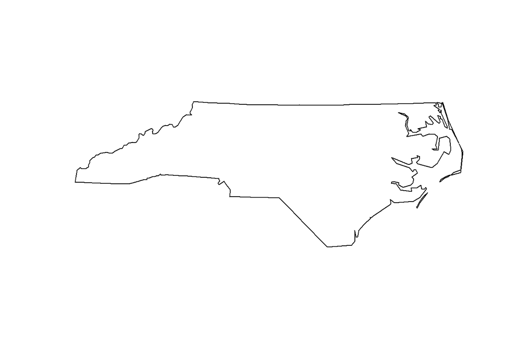

```r
plot(state_geom)
```

```r
state_geom$State="North Carolina"

st2<-state_geom%>%select(State)%>%
  st_set_agr(c(State="identity"))

st2%>%
  st_agr()
```

```
##    State
## identity
## Levels: constant aggregate identity
```

```r
st2
```

```
## Simple feature collection with 1 feature and 1 field
## Attribute-geometry relationship: 0 constant, 0 aggregate, 1 identity
## geometry type:  MULTIPOLYGON
## dimension:      XY
## bbox:           xmin: 123829 ymin: 14744.69 xmax: 930521.8 ymax: 318259.9
## epsg (SRID):    32119
## proj4string:    +proj=lcc +lat_1=36.16666666666666 +lat_2=34.33333333333334 +lat_0=33.75 +lon_0=-79 +x_0=609601.22 +y_0=0 +ellps=GRS80 +towgs84=0,0,0,0,0,0,0 +units=m +no_defs
##            State                   st_union.nc.
## 1 North Carolina MULTIPOLYGON (((834893.7 95...
```

*This variable State is now a `identity variable` because it represents the whole geometry*

## Exercise 3

Use `st_area` to add a variable with name `area` to `nc`. Compare the `area` and `AREA` variables in the `nc` dataset. What are the units of `AREA`? Are the two linearly related? If there are discrepancies, what could be the cause?

```r
nc$area=st_area(nc)
nc%>%select(NAME, AREA,area)
```

```
## Simple feature collection with 100 features and 3 fields
## geometry type:  MULTIPOLYGON
## dimension:      XY
## bbox:           xmin: 123829 ymin: 14744.69 xmax: 930521.8 ymax: 318259.9
## epsg (SRID):    32119
## proj4string:    +proj=lcc +lat_1=36.16666666666666 +lat_2=34.33333333333334 +lat_0=33.75 +lon_0=-79 +x_0=609601.22 +y_0=0 +ellps=GRS80 +towgs84=0,0,0,0,0,0,0 +units=m +no_defs
## # A tibble: 100 x 4
##    NAME      AREA area                                                 geom
##    <chr>    <dbl> <S3: unit>                             <MULTIPOLYGON [m]>
##  1 Ashe     0.114 113759816~ (((387344.8 278387.2, 381334.2 282773.7, 3794~
##  2 Allegha~ 0.061  61120784~ (((408601.8 292424.5, 408565.1 293985.3, 4066~
##  3 Surry    0.143 142374317~ (((478717.1 277490.3, 476935.7 278867.1, 4715~
##  4 Curritu~ 0.07   69467210~ (((878193.9 289128.3, 877381.5 291117.1, 8759~
##  5 Northam~ 0.153 152099621~ (((769835.3 277796.1, 768364.4 274841.8, 7626~
##  6 Hertford 0.097  96785742~ (((812328 277876.4, 791158.2 277011.9, 789882~
##  7 Camden   0.062  61605187~ (((878193.9 289128.3, 883270.9 275314.1, 8811~
##  8 Gates    0.091  90381791~ (((828444.6 290095.5, 824767.5 287166, 820818~
##  9 Warren   0.118 117952748~ (((671747.1 278687.7, 674043.1 282237.4, 6704~
## 10 Stokes   0.124 123299616~ (((517436.7 277857.7, 479040.3 279098.1, 4811~
## # ... with 90 more rows
```

$$L=\frac{2πr}{360}$$

*Calculating `L` and by replace `r`*

$$L=\frac{2π*6378000}{360}$$

## Exercise 4

Is the `area` variable intensive or extensive? Is its `agr` equal to `constant`, `identity` or `aggregate`?

```r
nc%>%select(NAME, AREA,area)%>%
  st_agr()
```

```
## NAME AREA area
## <NA> <NA> <NA>
## Levels: constant aggregate identity
```

*The `area` variable is extensive because of its property of `change` if it is splitted for example. It is mutable. It is `agr` is equal to `aggregate` according to its nature of being a “summary value over the geometry” [1]*

## Exercise 5

Find the name of the county that contains POINT(-78.34046 35.017)

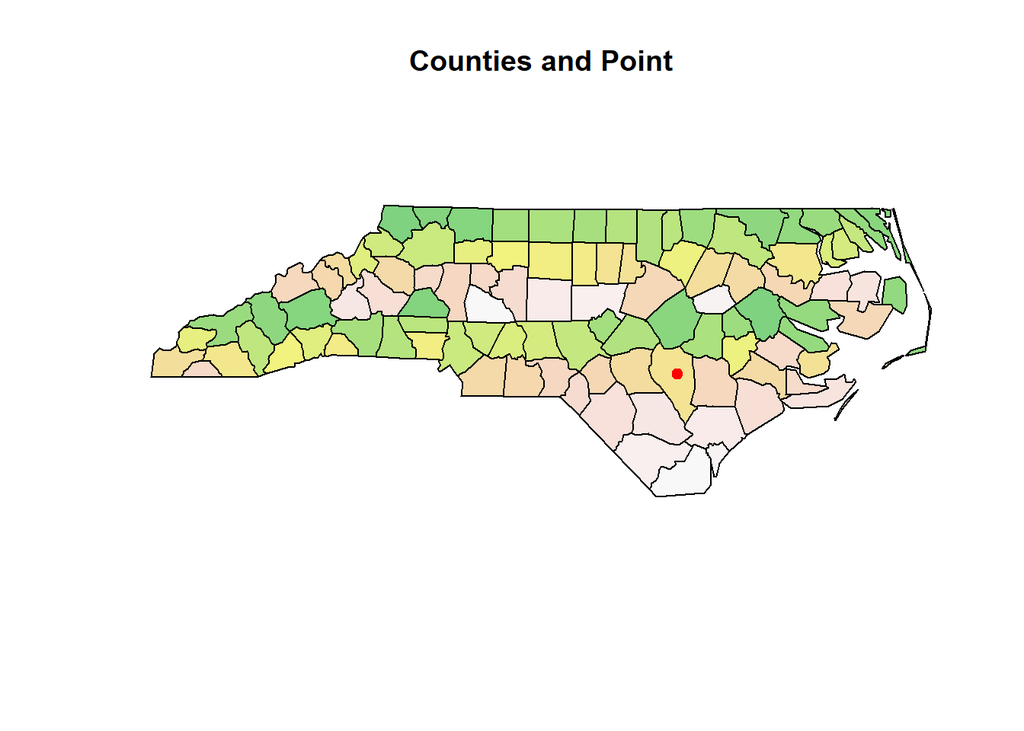

```r
#Create the point
look<-st_sfc(st_point(c(-78.34046,35.017)),crs=4326)
plot(st_geometry(st_transform(nc,4326)), col = terrain.colors(50,alpha=0.5),main="Counties and Point")
plot(look,col="red",pch = 19, add=TRUE)
```

```r
#Query the intersection
container=(st_intersects(look,st_transform(nc,4326)))
```

```
## although coordinates are longitude/latitude, st_intersects assumes that they are planar
## although coordinates are longitude/latitude, st_intersects assumes that they are planar
```

```r
states<-nc[unlist(container),]
states$NAME
```

```
## [1] "Sampson"
```

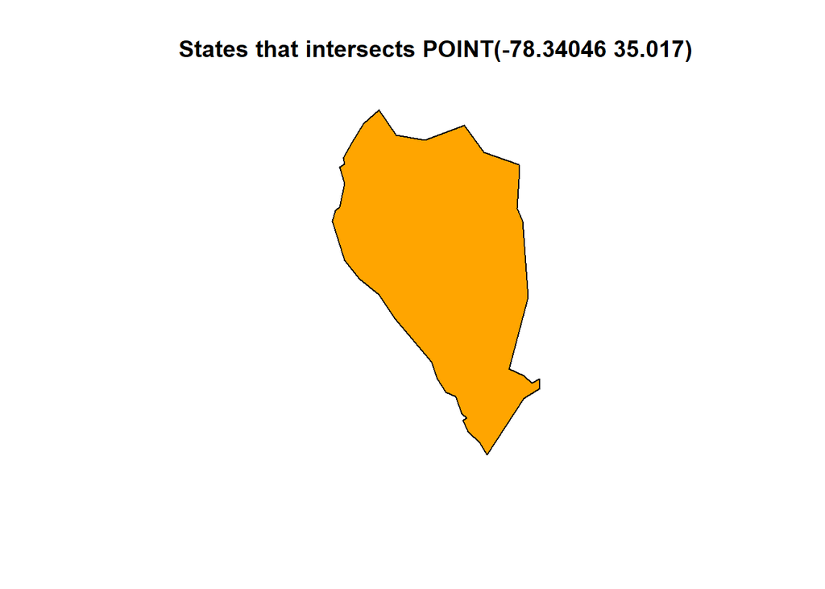

```r
#Ploting the result
plot(st_geometry(states),col="orange",main="States that intersects POINT(-78.34046 35.017)")
```

## Exercise 6

Find the names of all counties with boundaries that touch county `Sampson`.

```r
sampson= nc[nc$NAME == "Sampson", ]
sampson_to=nc[unlist(st_touches(sampson,nc)),]
#List of names
sampson_to$NAME
```

```
## [1] "Johnston"   "Wayne"      "Harnett"    "Cumberland" "Duplin"
## [6] "Bladen"     "Pender"
```

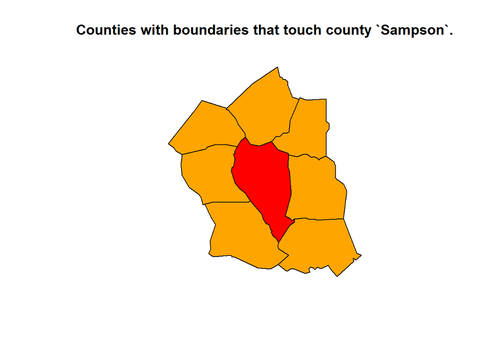

```r
plot(st_geometry(sampson_to),col="orange",main="Counties with boundaries that touch county `Sampson`.")
plot(st_geometry(sampson), col="red",add=TRUE)
```

## Exercise 7

List the names of all counties that are less than 50 km away from county `Sampson`.

```r
sampson_close=nc[unlist(st_is_within_distance(sampson,nc,dist=50000)),]
sampson_close$NAME
```

```
##  [1] "Wake"        "Chatham"     "Wilson"      "Johnston"    "Greene"
##  [6] "Lee"         "Wayne"       "Harnett"     "Moore"       "Lenoir"
## [11] "Sampson"     "Cumberland"  "Jones"       "Hoke"        "Duplin"
## [16] "Onslow"      "Robeson"     "Bladen"      "Pender"      "Columbus"
## [21] "New Hanover" "Brunswick"
```

For the following exercises, we will work with naturalearth:

```r
library(rnaturalearth)
e = ne_countries(returnclass = "sf")["pop_est"]
```

## Exercise 8

Plot the variable pop_est. Which projection is used?

```r
e
```

```
## Simple feature collection with 177 features and 1 field
## geometry type:  MULTIPOLYGON
## dimension:      XY
## bbox:           xmin: -180 ymin: -90 xmax: 180 ymax: 83.64513
## epsg (SRID):    4326
## proj4string:    +proj=longlat +datum=WGS84 +no_defs
## First 10 features:
##    pop_est                       geometry
## 0 28400000 MULTIPOLYGON (((61.21082 35...
## 1 12799293 MULTIPOLYGON (((16.32653 -5...
## 2  3639453 MULTIPOLYGON (((20.59025 41...
## 3  4798491 MULTIPOLYGON (((51.57952 24...
## 4 40913584 MULTIPOLYGON (((-65.5 -55.2...
## 5  2967004 MULTIPOLYGON (((43.58275 41...
## 6     3802 MULTIPOLYGON (((-59.57209 -...
## 7      140 MULTIPOLYGON (((68.935 -48....
## 8 21262641 MULTIPOLYGON (((145.398 -40...
## 9  8210281 MULTIPOLYGON (((16.97967 48...
```

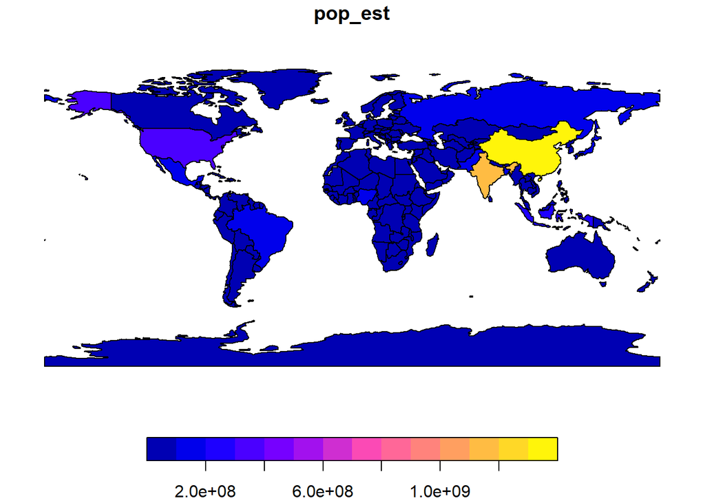

```r
plot(e)
```

*The projection used is WGS84*

## Exercise 9

Plot the variable converted to +proj=ortho, see here. What happened to Antarctica?

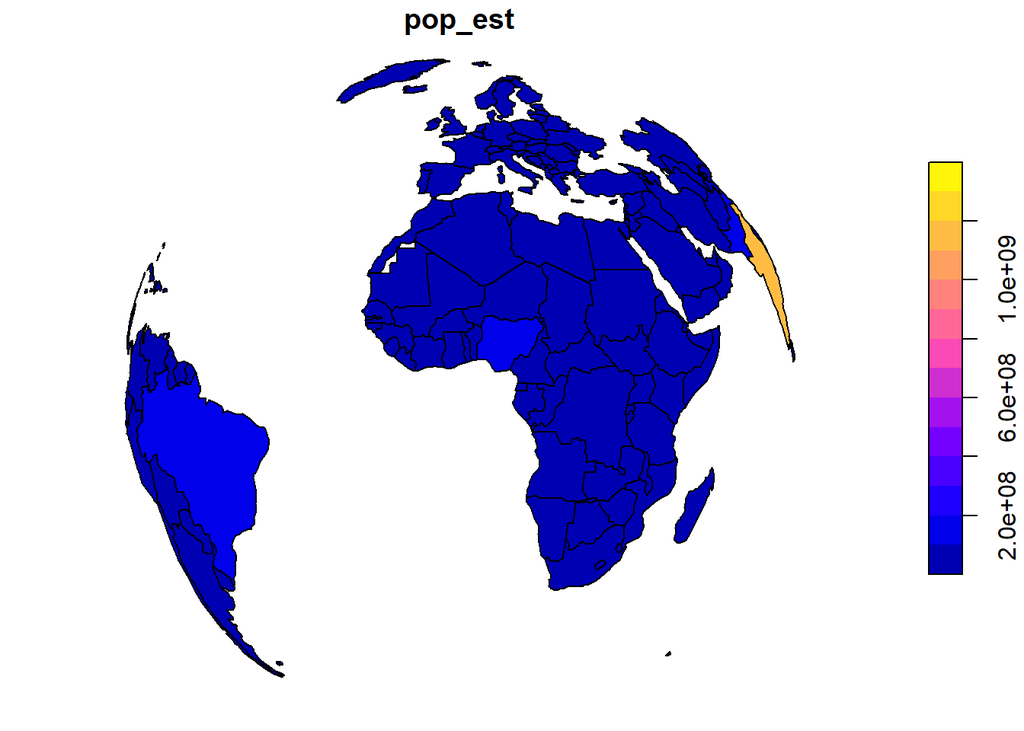

```r
e2<-st_transform(e,st_crs("+proj=ortho"))
plot(e2)
```

*Antarctica is no longer visible in the plot*

## Exercise 10

Plot the same data with the ortho projection, adding `lat_0=-90`, `lat_0=90`, `lon_0=90`, `lon_0=-90` for four different views. Try to explain what happens.

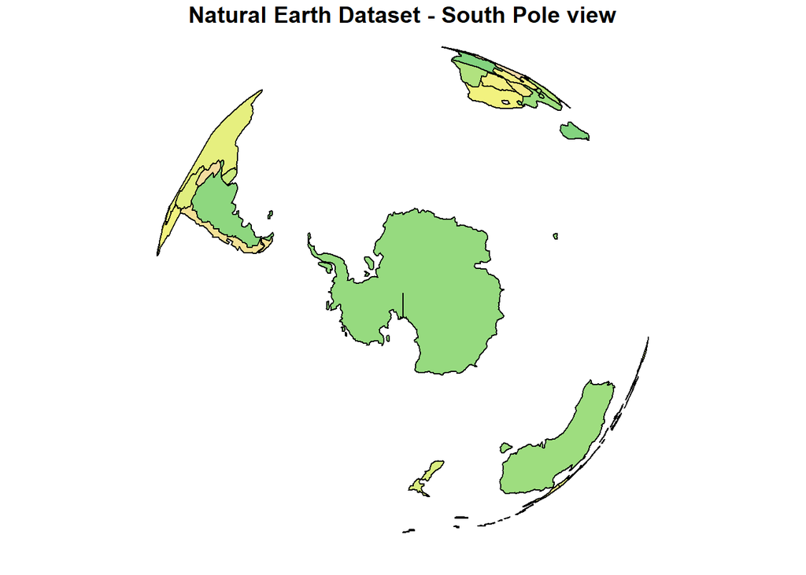

```r
plot(st_transform(e,st_crs("+proj=ortho +lat_0=-90")),col = terrain.colors(50,alpha=0.5),main="Natural Earth Dataset - South Pole view")
```

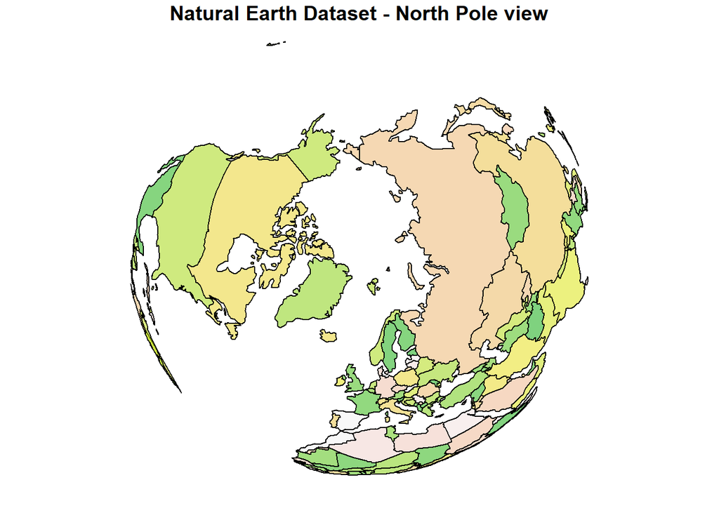

```r
plot(st_transform(e,st_crs("+proj=ortho +lat_0=90")),col = terrain.colors(50,alpha=0.5),main="Natural Earth Dataset - North Pole view")
```

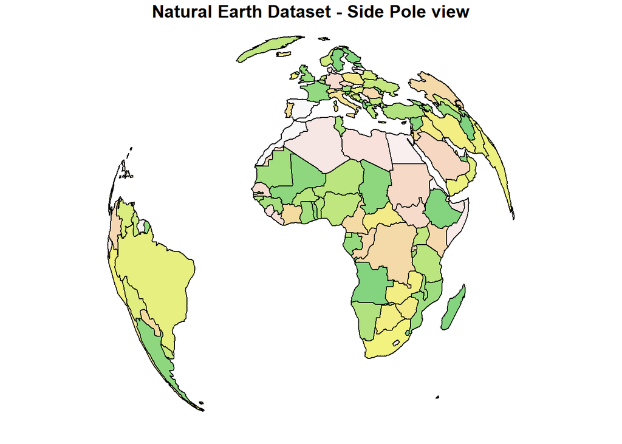

```r
plot(st_transform(e,st_crs("+proj=ortho +long_0=90")),col = terrain.colors(50,alpha=0.5),main="Natural Earth Dataset - Side Pole view")
```

```r
plot(st_transform(e,st_crs("+proj=ortho +long_0=-90")),col = terrain.colors(50,alpha=0.5),main="Natural Earth Dataset - Side Pole view")
```

[output not shown]

## Exercise 11

Create a polygon of the northern hemisphere. Use that to get the intersection with e, and plot that with `lat_0=90`.

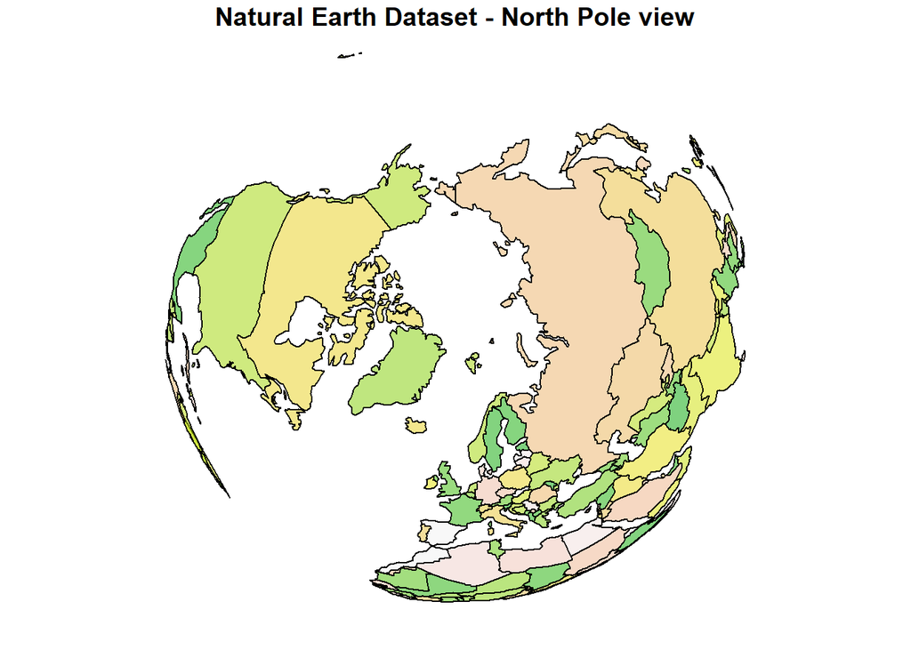

```r
#Get North Hemisphere
hnorth<-st_transform(e,st_crs("+proj=ortho +lat_0=90"))
plot(hnorth,col = terrain.colors(50,alpha=0.5),main="Natural Earth Dataset - North Pole view")
```

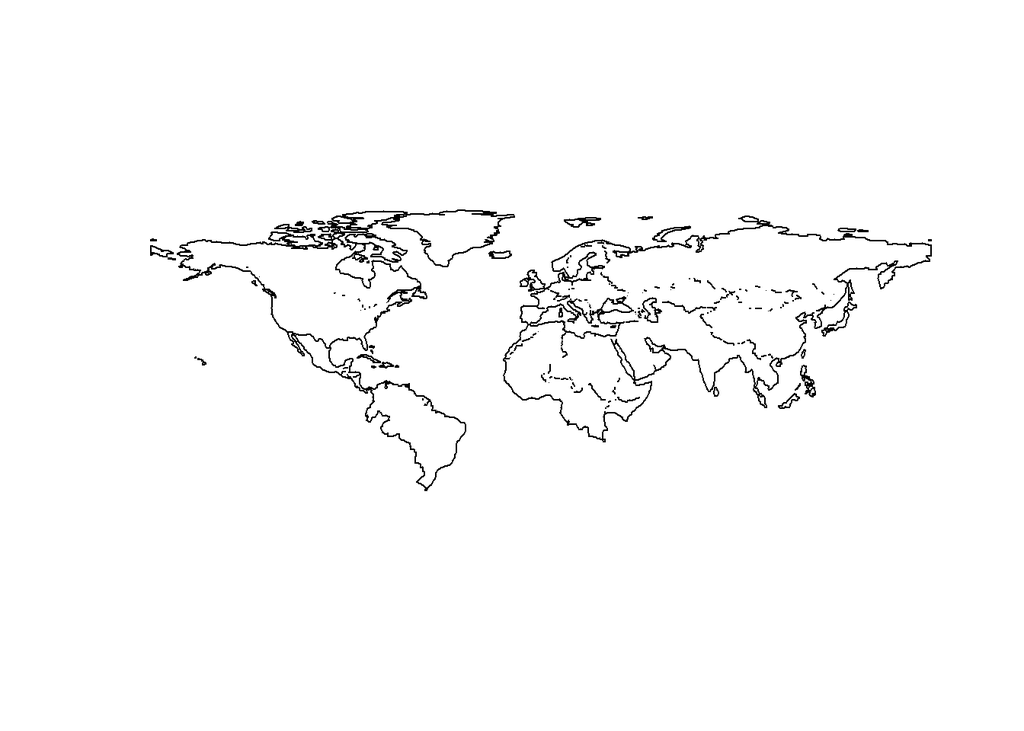

```r
#Create a unique geometry
hnorthclean<-st_union(st_geometry(e[unlist((!is.na(st_dimension(hnorth)))),]))
plot(hnorthclean)
```

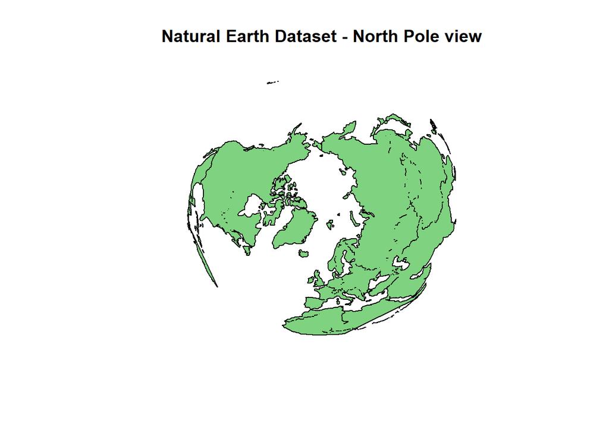

```r
#Plot the new geometry from pole north view
hnorthcleanview<-st_transform(hnorthclean,st_crs("+proj=ortho +lat_0=90"))
plot(hnorthcleanview,col = terrain.colors(50,alpha=0.5),main="Natural Earth Dataset - North Pole view")
```

```r
#Intersection with e
(result<-st_intersects(hnorthclean,e,sparse=FALSE))
```

```
## although coordinates are longitude/latitude, st_intersects assumes that they are planar
```

[output not shown]

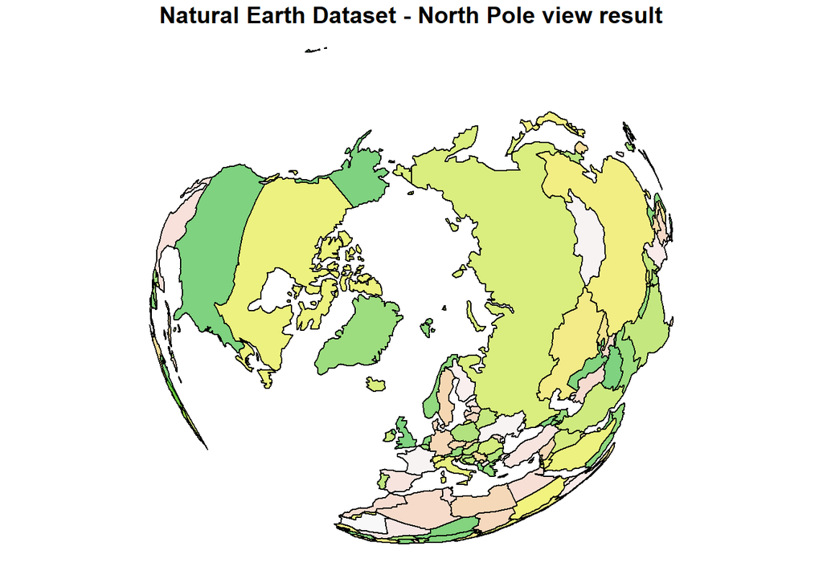

```r
geom_in<-e[unlist(result),]

result2<-st_transform(geom_in,st_crs("+proj=ortho +lat_0=90"))
#Intersection plotting
plot(result2,col = terrain.colors(50,alpha=0.5),main="Natural Earth Dataset - North Pole view result")
```

## Exercise 12

For the land mass between latitudes 45 and 55 and longitudes 0 and 10, estimate the total population as well as the average population.

```r
landmass<-st_crop(e, c(xmin=0, xmax=10, ymin=45, ymax=55))
```

```
## although coordinates are longitude/latitude, st_intersection assumes that they are planar
```

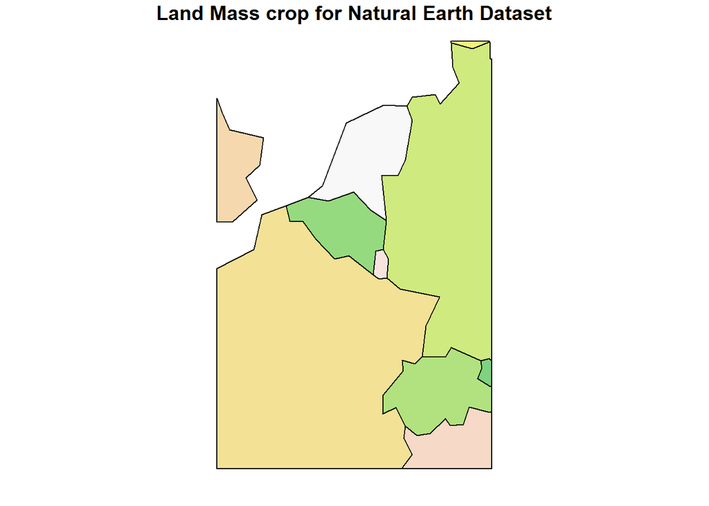

```r
plot(landmass,col = terrain.colors(10,alpha=0.5),main="Land Mass crop for Natural Earth Dataset")
```

```r
(total_pop=sum(landmass$pop_est))
```

```
## [1] 315713130
```

```r
(avg_pop=mean(landmass$pop_est))
```

```
## [1] 31571313
```

## References

*[1] Spatial Data Science* https://keen-swartz-3146c4.netlify.com/

*[2] R Documentation* https://www.rdocumentation.org

*[3] sf Github* https://r-spatial.github.io/sf/articles/sf1.html